# report

## a)

The main challenge under this configuration is dealing the with the correlation between the products of the basket. As the VaR is not additive, figures of components of a basket do not add to the risk of the overall basket. This is because this measure does not take correlations into account and a simple addition could lead to double counting and underestimating the risk, especially when the tail dependence is rather high.

## b)

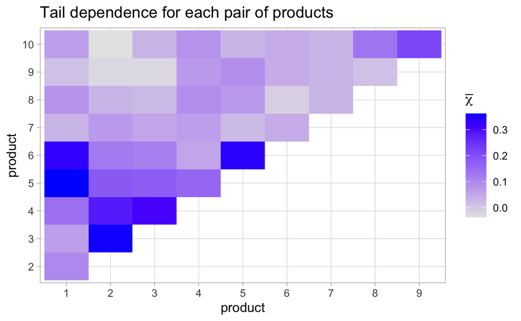

The tail dependence can be measured thanks to the $\bar{\chi}$ metric and is given by the following equation :
$$\bar{\chi}(u) = 2*log(Pr[U > u])/log(Pr[U > u, V > u]) - 1$$

Figure @ref(fig:chibar) displays this mesure of dependence for each pair of products at the 90% quantile. We may easily notice that certain pairs of products are highly tail dependent.

| Product pair | $\bar{\chi}$ |
| --- | --- |
| 1-5 | 0.362 |
| 2-3 | 0.355 |
| 5-6 | 0.337 |
| 1-6 | 0.330 |
| 3-4 | 0.304 |

Table @ref(tab:topchibar) shows the top five pairs of product in terms of tail dependence.

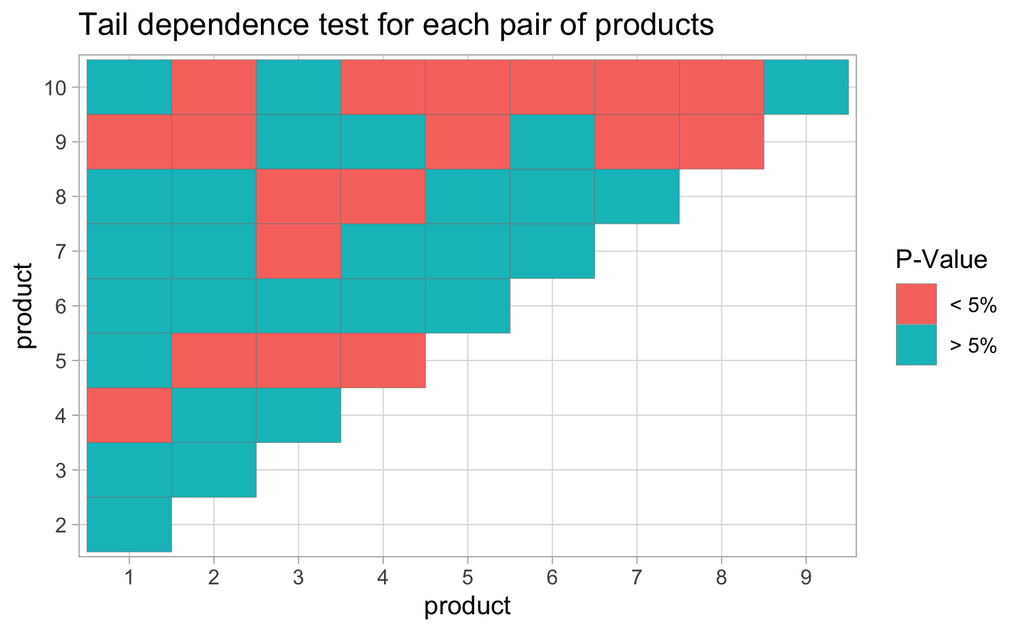

We may also apply a tail dependence test for each pair of products, the null hypothesis being the tail dependence. Figure @ref(fig:pavalchi) shows that a majority of pair of products may be considered tail dependent since their p-value is superior to 5% for a probability thresold of 90%.

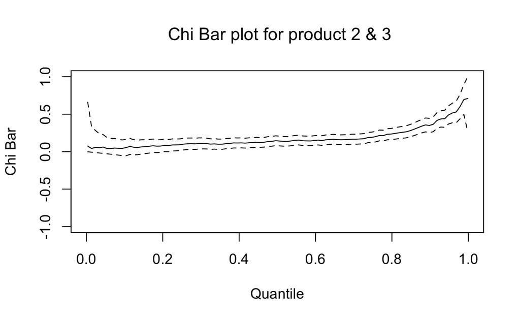

Chi Bar plot may also be usefull to detect tail dependency. As shown on Graph @ref(fig:chiplothigh) , products 2 & 3 look strongly dependent in the upper tail.

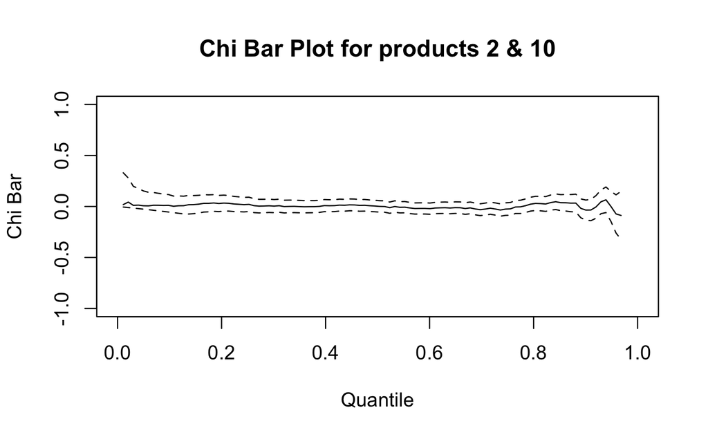

Conversly, Figure @ref(fig:chiplotlow) shows low tail-dependence for product 2 & 10.

## c)

The Gaussian copula is asymptotically independent in both upper and lower tails. Since a majority of pairs are dependent in upper tail, the Gaussian copula seems inappropriate as it would lead to an under estimation of the VaR.

## d)

### .i

Prior to fitting the Copula, we apply a uniform transformation to the data. A gdp is fitted on data points above a thresold corresponding to the 90% quantile for each products. The instances below this quantile are treated in a different manner and are uniformised using their empircal cumulative distribution.

### .ii

Copula

Parameter 1

Parameter 2

Log-Likelihood

AIC

T

0.070

9.514

256.1

-508

Gumbel

1.074

170.1

-338

Gauss

0.084

128.8

-256

Clayton

0.056

87.8

-174

Table @ref(tab:resultscopu) displays the Coppulas that have been fitted to the transformed data. With an AIC of -508, the T coppula suits the best the data and will be retained for the following of our analysis.

### .iii

After selecting the best coppula, we generate 1913 instances for each products to which we apply the inverse of the transformation that has been made in point i.

### .iv

The Value at Risk for the simulated data is obtained by taking the 95 % quantile of the row sums and corresponds to 111.332